# Micro proyecto 2

## Enunciado

### Alcanzando los objetivos de desarrollo sostenible. Un aporte desde el machine learning

La Organización de las Naciones Unidas (ONU) adopta, el 25 de septiembre del año 2015, la Agenda 2030 para el desarrollo sostenible, cuyo fin es reducir la pobreza, garantizar acceso a la salud y educación, buscar igualdad de género y oportunidades y disminuir el impacto ambiental, entre otros propósitos. A tal efecto, define 17 objetivos de desarrollo sostenible (ODS) y 169 metas (derivadas de los diferentes ODS). Dentro del trabajo en conjunto de diferentes entes para alcanzar el cumplimiento de los objetivos de desarrollo sostenible definidos en la Agenda 2030, muchas entidades tienen como función el seguimiento y la evaluación de las políticas públicas y su impacto a nivel social. Este es el caso del Fondo de Población de las Naciones Unidas (UNFPA, por sus siglas en inglés), que, junto con instituciones públicas y haciendo uso de diferentes herramientas de participación ciudadana, busca identificar problemas y evaluar soluciones actuales, relacionando la información con los diferentes ODS.

Uno de los procesos que requiere de un mayor esfuerzo es la interpretación y análisis de la información textual procedente de diferentes fuentes implicadas en la planeación participativa para el desarrollo a nivel territorial, ya que es una tarea que consume gran cantidad recursos y para la cual se requiere de expertos que relacionen los textos con los ODS. Este conocimiento facilitaría la toma de decisiones con base en la opinión de la población y permitiría encaminar las políticas públicas de manera más informada para el cumplimiento de la Agenda 2030.

El objetivo del proyecto es desarrollar una solución, basada en técnicas de procesamiento del lenguaje natural y machine learning, que permita clasificar automáticamente un texto según los 17 ODS, ofreciendo una forma de presentación de resultados a través de una herramienta de fácil comprensión para el usuario final.

**A. Objetivo.**

Desarrollar una solución, basada en técnicas de procesamiento de lenguaje natural y machine learning, que facilite la interpretación y análisis de información textual para la identificación de relaciones semánticas con los Objetivos de Desarrollo Sostenibles.

**B. Conjunto de datos**

El conjunto de datos forma parte del proyecto “OSDG Community Dataset” ([OSDG-CD](https://zenodo.org/records/5550238)), en su versión 2023, que contiene un total de 40.067 textos, de los cuales 3000 provienen de fuentes relacionadas con las Naciones Unidas. También contiene documentos públicos, resúmenes de artículos y reportes. La plataforma reúne investigadores, expertos en la materia y defensores de los ODS de todo el mundo para crear una fuente amplia y precisa de información textual sobre los ODS. Los voluntarios de la comunidad utilizan la plataforma para participar en ejercicios de etiquetado en los que validan la relevancia de cada texto para los ODS basándose en sus conocimientos previos.

Los textos que serán utilizados en este proyecto fueron traducidos al español utilizando herramientas como [Deepl](https://www.deepl.com/docs-api). También se realizó una aumentación de textos a través del API de [ChatGPT](https://chat.openai.com/g/g-I1XNbsyDK-api-docs). Los puedes descargar a partir de: Archivo adjunto

**C. Actividades para realizar**

1. Preparación de los textos utilizando el esquema de bolsa de palabras (BOW)l con una pesado TF-IDF. Para este paso construir un pipeline que integre las transformaciones que se consideren adecuadas.
2. A partir de la matriz TF-IDF construida en el paso anterior, aplica el algoritmo SVD truncado (TruncatedSVD de scikit-learn) para obtener un modelo de tópicos mediante análisis semántico latente (LSA). Explora un número reducido de componentes (por ejemplo, entre 10 y 20) y, para al menos 5 de ellas, identifica y muestra las palabras con mayor peso (loadings), a modo de "tópicos". Interpreta cualitativamente si estos tópicos guardan relación con algunos de los 17 ODS trabajados en el proyecto.
3. Desarrollo de un modelo de clasificación que permita relacionar un texto con un ODS. Para manejar la complejidad del espacio de entrada, puedes reutilizar la misma descomposición SVD obtenida en la actividad anterior (LSA), o aplicar otro algoritmo de reducción de la dimensionalidad que consideres pertinente
4. Evaluación del modelo de clasificación con textos que no hayan sido utilizados para el aprendizaje.

**D. Consideraciones**

El algoritmo de clasificación a utilizar, así como la técnica de reducción de la dimensionalidad, queda a consideración de cada grupo, pero es importante justificar la elección.

**E. Entregable**

Notebook (*.ipynb y *.html) del método desarrollado. El Notebook debe estar documentado con las justificaciones de las decisiones tomadas en cada paso. Además, deben ser visibles las ejecuciones de cada celda. Para evidenciar el desempeño del método construido el notebook debe mostrar las clasificaciones para al menos cuatro textos del conjunto test.

Esta entrega debe realizarse al final de la semana 7, en donde encontrarás un espacio para adjuntar los dos archivos.

**F. Criterios de evaluación**

[output not shown]

**G. Bonificación adicional (opcional)**

Con el propósito de fortalecer las competencias en despliegue y aplicación práctica de modelos de machine learning, se otorgará una bonificación adicional de 15 puntos a los grupos que, de manera voluntaria, implementen el modelo desarrollado en una aplicación interactiva utilizando Streamlit. La aplicación deberá:

- Permitir al usuario ingresar un texto libre.
- Procesar el texto utilizando el mismo pipeline construido en el proyecto.
- Generar como salida la predicción del Objetivo de Desarrollo Sostenible (ODS) correspondiente.
- Ser funcional y ejecutarse correctamente.

La asignación de los 15 puntos dependerá del correcto funcionamiento de la aplicación y la claridad en la interacción con el usuario.

Esta bonificación es opcional y no reemplaza ninguno de los criterios establecidos en la rúbrica; corresponde a un reconocimiento adicional por llevar el modelo más allá del entorno experimental hacia un escenario de uso práctico.

En la actividad de entrega del microproyecto número 2 junto con el notebook, incorpore la url de despliegue desarrollada por su equipo y la url de su repositorio de GIT usada en el proceso.

```python
%pip install -q --upgrade numpy matplotlib scikit-learn
```

### Imports

Importamos las librerías que vamos a utilizar durante el desarrollo de la actividad

```python
from pathlib import Path
import unicodedata

import matplotlib.pyplot as plt
import numpy as np
import pandas as pd

import nltk
from nltk import RegexpTokenizer
from nltk.corpus import stopwords
from nltk.stem import SnowballStemmer

from IPython.display import display
from sklearn.decomposition import TruncatedSVD
from sklearn.feature_extraction.text import TfidfVectorizer
from sklearn.linear_model import LogisticRegression
from sklearn.metrics import classification_report, ConfusionMatrixDisplay, confusion_matrix
from sklearn.model_selection import train_test_split, GridSearchCV, StratifiedKFold
from sklearn.pipeline import Pipeline
from sklearn.preprocessing import Normalizer
from wordcloud import WordCloud
```

### Definición de constantes

Definimos las constantes que vamos a utilizar durante el proyecto

```python
STATE = 42
DATA_PATH = Path("data/Datos_textosODS.xlsx")
nltk.download('stopwords', quiet=True)
```

```
True
```

### Carga de los datos

```python
raw_data = pd.read_excel(DATA_PATH, sheet_name="Sheet1")

raw_data
```

|  | textos | ODS |
| --- | --- | --- |
| 0 | "Aprendizaje" y "educación" se consideran sinó... | 4 |
| 1 | No dejar clara la naturaleza de estos riesgos ... | 6 |
| 2 | Como resultado, un mayor y mejorado acceso al ... | 13 |
| 3 | Con el Congreso firmemente en control de la ju... | 16 |
| 4 | Luego, dos secciones finales analizan las impl... | 5 |
| ... | ... | ... |
| 9651 | Esto implica que el tiempo de las mujeres en e... | 5 |
| 9652 | Sin embargo, estas fallas del mercado implican... | 3 |
| 9653 | El hecho de hacerlo y cómo hacerlo dependerá e... | 9 |
| 9654 | Esto se destacó en el primer estudio de caso, ... | 6 |
| 9655 | Aunque existen programas para convertirse espe... | 4 |

9656 rows × 2 columns

Vamos a evaluar si se requiere realizar limpieza de datos

```python
def fill_na(text_set):
    return text_set.fillna('').astype(str)
def normalize_text(text_set):
    return text_set.map(lambda x: unicodedata.normalize('NFKC', x)).str.lower()
def remove_spaces(text_set):
    return text_set.str.replace(r'\\s+', ' ', regex=True).str.strip()
def normalize_text_pipeline(text_set):
    return remove_spaces(normalize_text(fill_na(text_set)))

normalized_text = normalize_text_pipeline(raw_data['textos'])

quality_checks = pd.Series({
    'Textos faltantes': raw_data['textos'].isna().sum(),
    'Etiquetas faltantes': raw_data['ODS'].isna().sum(),
    'Textos vacíos': normalized_text.eq('').sum(),
    'Filas duplicadas': raw_data.duplicated().sum(),
    'Textos repetidos normalizados': normalized_text.duplicated().sum(),
    'Textos con etiquetas contradictorias': raw_data.assign(normalized_text=normalized_text).groupby('normalized_text')['ODS'].nunique().gt(1).sum(),
    'Etiquetas fuera de 1 a 17': raw_data['ODS'].between(1, 17).eq(False).sum()
})

display(raw_data.head())
display(quality_checks.to_frame('Cantidad'))
```

|  | textos | ODS |
| --- | --- | --- |
| 0 | "Aprendizaje" y "educación" se consideran sinó... | 4 |
| 1 | No dejar clara la naturaleza de estos riesgos ... | 6 |
| 2 | Como resultado, un mayor y mejorado acceso al ... | 13 |
| 3 | Con el Congreso firmemente en control de la ju... | 16 |
| 4 | Luego, dos secciones finales analizan las impl... | 5 |

|  | Cantidad |
| --- | --- |
| Textos faltantes | 0 |
| Etiquetas faltantes | 0 |
| Textos vacíos | 0 |
| Filas duplicadas | 0 |
| Textos repetidos normalizados | 0 |
| Textos con etiquetas contradictorias | 0 |
| Etiquetas fuera de 1 a 17 | 0 |

No tenemos datos duplicados ni nulos, así que no debemos realizar limpieza de datos

Ahora definimos los nombres de cada una de las categorías de las ODS

```python
ods_names = {
    1: "Fin de la pobreza", 2: "Hambre cero", 3: "Salud y bienestar",
    4: "Educación de calidad", 5: "Igualdad de género",
    6: "Agua limpia y saneamiento", 7: "Energía asequible y no contaminante",
    8: "Trabajo decente y crecimiento económico",
    9: "Industria, innovación e infraestructura",
    10: "Reducción de las desigualdades", 11: "Ciudades y comunidades sostenibles",
    12: "Producción y consumo responsables", 13: "Acción por el clima",
    14: "Vida submarina", 15: "Vida de ecosistemas terrestres",
    16: "Paz, justicia e instituciones sólidas", 17: "Alianzas para lograr los objetivos"
}
```

Y los utilizamos para mostrar la distribución de datos en estas categorías de una manera más explicativa

|  | ODS | Nombre | Textos | Porcentaje |
| --- | --- | --- | --- | --- |
| 0 | 1 | Fin de la pobreza | 505 | 5.23 |
| 1 | 2 | Hambre cero | 369 | 3.82 |
| 2 | 3 | Salud y bienestar | 894 | 9.26 |
| 3 | 4 | Educación de calidad | 1025 | 10.62 |
| 4 | 5 | Igualdad de género | 1070 | 11.08 |
| 5 | 6 | Agua limpia y saneamiento | 695 | 7.20 |
| 6 | 7 | Energía asequible y no contaminante | 787 | 8.15 |
| 7 | 8 | Trabajo decente y crecimiento económico | 446 | 4.62 |
| 8 | 9 | Industria, innovación e infraestructura | 343 | 3.55 |
| 9 | 10 | Reducción de las desigualdades | 352 | 3.65 |
| 10 | 11 | Ciudades y comunidades sostenibles | 607 | 6.29 |
| 11 | 12 | Producción y consumo responsables | 312 | 3.23 |
| 12 | 13 | Acción por el clima | 464 | 4.81 |
| 13 | 14 | Vida submarina | 377 | 3.90 |
| 14 | 15 | Vida de ecosistemas terrestres | 330 | 3.42 |
| 15 | 16 | Paz, justicia e instituciones sólidas | 1080 | 11.18 |
| 16 | 17 | Alianzas para lograr los objetivos | 0 | 0.00 |

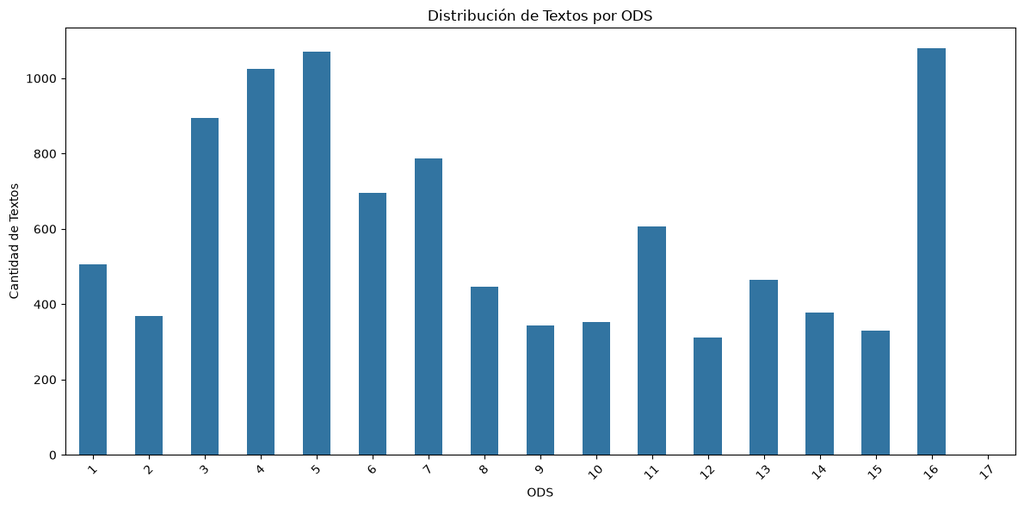

```
ODS ausentes: ['Alianzas para lograr los objetivos']
```

```python
class_counts = raw_data['ODS'].value_counts().reindex(range(1, 18), fill_value=0).sort_index()

distribution_df = pd.DataFrame({
    'ODS': class_counts.index,
    'Nombre': class_counts.index.map(ods_names),
    'Textos': class_counts.values,
    'Porcentaje': (class_counts.values / class_counts.sum() * 100).round(2)
})

display(distribution_df)
class_counts.plot(kind='bar', figsize=(12, 6), color='#3274A1', xlabel='ODS', ylabel='Cantidad de Textos', title='Distribución de Textos por ODS')
plt.xticks(rotation=45)
plt.tight_layout()
plt.show()

print('ODS ausentes:', distribution_df.loc[distribution_df['Textos'].eq(0), 'Nombre'].tolist())
```

De acuerdo al analisis anterior, podemos evidenciar que en el conjunto de datos, no se encuentran todos los ODS sino que hace falta uno, el 17. Ahora las clases con más y menos datos son: el ODS 16 que tiene 1.080 textos como el de mayor cantidad y el ODS 12 que tiene 312 como la clase con menor cantidad de datos. Es un desbalance moderado que puede favorecer las clases frecuentes si solo se considera la exactitud. Por eso se utilizará F1 macro para seleccionar el clasificador y se comparará la ponderación de clases automática con la ausencia de ponderación.

### Separación de datos

Seleccionamos la variable objetivo del conjunto de datos, dejando en `X` los textos para el modelo.

Reservamos el 20% de los datos para test y usamos el 80% restante para entrenar y seleccionar hiperparámetros. La división estratificada conserva aproximadamente la distribución de los ODS; es viable porque todas las clases presentes tienen cientos de ejemplos.

El vocabulario, las frecuencias IDF y la descomposición SVD se aprenderán únicamente con entrenamiento. El test queda reservado para una evaluación final, sin intervenir en la selección del modelo.

```python
X = raw_data['textos']
y = raw_data['ODS']

X_train, X_test, y_train, y_test = train_test_split(X, y, test_size=0.2, stratify=y, random_state=STATE)

print("X_train shape:", X_train.shape)
print("X_test shape:", X_test.shape)
```

```
X_train shape: (7724,)
X_test shape: (1932,)
```

## BOW

Para la construcción de la bolsa de palabras, exploramos los distintos pasos necesarios para la preparación de texto el cual consta de tokenización, eliminación de stop-words y stemming.

Preparamos las instancias que vamos a necesitar

```python
ES_stopwords = set(stopwords.words('spanish'))
ES_stemmer = SnowballStemmer('spanish')
```

### Tokenización

Utilizamos un RegexpTokenizer, para hacer match de palabras utilizando expresiones regulares, eliminando así símbolos, espacios, números, y cualquier otro que no sea considerado una palabra.

```python
tokenizer = RegexpTokenizer(r'\w+')
tokenized = X_train.apply(lambda x: tokenizer.tokenize(x))
tokenized
```

```
2376    [Por, lo, tanto, cabe, esperar, que, el, aumen...
7665    [La, tasa, aumenta, con, el, tiempo, y, finalm...
3811    [Su, objetivo, es, mejorar, las, respuestas, q...
1267    [La, mayor, parte, de, la, producción, acuícol...
2770    [Según, datos, del, Ministerio, de, Infancia, ...
                              ...
5845    [Este, estudio, tiene, como, objetivo, determi...
7625    [Y, a, pesar, de, la, ausencia, de, una, ley, ...
2065    [La, tasa, de, recaudación, de, tarifas, cayó,...
15      [Las, guerras, los, conflictos, armados, y, la...
7915    [La, desigualdad, socioeconómica, es, un, prob...
Name: textos, Length: 7724, dtype: object
```

### StopWords

Eliminamos las palabras vacías o stop-words utilizando el paquete en español de `stopwords`, con esto eliminamos aquellas palabras que no aporten un significado semántico a las frases como lo son los conectores o los artículos.

```python
no_stopwords = tokenized.apply(lambda x: [word for word in x if word.lower() not in ES_stopwords])
no_stopwords
```

```
2376    [cabe, esperar, aumento, niveles, ingresos, po...
7665    [tasa, aumenta, tiempo, finalmente, número, su...
3811    [objetivo, mejorar, respuestas, reciben, servi...
1267    [mayor, parte, producción, acuícola, seguirá, ...
2770    [Según, datos, Ministerio, Infancia, Educación...
                              ...
5845    [estudio, objetivo, determinar, implementación...
7625    [pesar, ausencia, ley, competencia, inversores...
2065    [tasa, recaudación, tarifas, cayó, 86, ingreso...
15      [guerras, conflictos, armados, ocupación, terr...
7915    [desigualdad, socioeconómica, problema, distin...
Name: textos, Length: 7724, dtype: object
```

### Nube de palabras

Llegados a este punto, podemos graficar una nube de palabras con la que podremos identificar las palabras con mayor peso en todo el corpus, se destacan las palabras "política", "embargo", "mujeres", "ejemplo", "sistema", "desarrollo", entre otras, dando a entender (al menos superficialmente) los temas principales del conjunto de datos.

[figure not shown]

```python
wc_text = ' '.join(word for text in no_stopwords for word in text)

wordcloud = WordCloud(
        width=800,
        height=400,
        background_color='white',
        min_font_size=10,
        max_font_size=110
    ).generate(wc_text)

plt.figure(figsize=(10, 10))
plt.imshow(wordcloud)
plt.axis('off')
plt.show()
```

### Stemming

Vamos a reducir cada token a su forma más general con el proceso de stemming, para este caso nuestro conjunto de datos está escrito en español, por lo que se opta por utilizar el `SnowballStemmer` pues tiene soporte para múltiples idiomas de acuerdo a la [documentaicón oficial](https://www.nltk.org/howto/stem.html).

```python
stemmed = no_stopwords.apply(lambda x: [ES_stemmer.stem(word) for word in x])
stemmed
```

```
2376    [cab, esper, aument, nivel, ingres, posterior,...
7665    [tas, aument, tiemp, final, numer, suficient, ...
3811    [objet, mejor, respuest, recib, servici, perso...
1267    [mayor, part, produccion, acuicol, segu, orig,...
2770    [segun, dat, ministeri, infanci, educ, iguald,...
                              ...
5845    [estudi, objet, determin, implement, concept, ...
7625    [pes, ausenci, ley, competent, inversor, parec...
2065    [tas, recaud, tarif, cay, 86, ingres, tas, usu...
15      [guerr, conflict, armad, ocup, territori, menu...
7915    [desiguald, socioeconom, problem, disting, fro...
Name: textos, Length: 7724, dtype: object
```

### Texto procesado

Vamos a inspeccionar visualmente el resultado del proceso anterior, volviendo a armar las frases completas que ya fueron pre-procesadas. Esto nos ayuda a visualizar la forma en que serán interpretadas las frases por el modelo.

```python
processed = stemmed.apply(lambda x: ' '.join(x))
processed
```

```
2376    cab esper aument nivel ingres posterior reform...
7665    tas aument tiemp final numer suficient organiz...
3811    objet mejor respuest recib servici person situ...
1267    mayor part produccion acuicol segu orig pais a...
2770    segun dat ministeri infanci educ iguald gener ...
                              ...
5845    estudi objet determin implement concept buen g...
7625    pes ausenci ley competent inversor parec quej ...
2065    tas recaud tarif cay 86 ingres tas usuari cubr...
15      guerr conflict armad ocup territori menud cond...
7915    desiguald socioeconom problem disting fronter ...
Name: textos, Length: 7724, dtype: object
```

Podemos condensar todo el proceso anterior en la siguiente función, la cual también nos será de utilidad para datos nuevos que se quieran procesar con el modelo entrenado.

```python
def text_analyzer(text):
    normalized = unicodedata.normalize('NFKC', text).lower()
    tokenized = tokenizer.tokenize(normalized)
    no_stopwords = [word for word in tokenized if word.lower() not in ES_stopwords]
    stemmed = [ES_stemmer.stem(word) for word in no_stopwords]

    return stemmed
```

### Nube de vocabularios

A continuación queremos graficar la nube de palabras con mayor peso generada por el TF-IDF Vectorizer, utilizando la función de pre procesamiento anterior

**Implementamos LSA**

Utilizando la clase de TruncatedSVD realizamos el agrupamiento de palabras con significados similares. Exploraremos la cantidad de componentes `n_components` [10, 15, 20], dentro del rango sugerido en el enunciado. Comparamos la varianza explicada acumulada. Esta exploración utiliza solo los textos de entrenamiento.

```python
cloud_vectorizer = TfidfVectorizer(analyzer=text_analyzer, max_features=500)
X_tfidf = cloud_vectorizer.fit_transform(X_train)

lsa_models = {}
lsa_summary = []
n_topics = [10, 15, 20]

for n in n_topics:
    lsa = TruncatedSVD(n_components=n, n_iter=10, random_state=STATE)
    lsa_model = lsa.fit(X_tfidf)
    lsa_models[n] = lsa_model
    lsa_summary.append({'Componentes': n, 'Varianza explicada': lsa_model.explained_variance_ratio_.sum()})

display(pd.DataFrame(lsa_summary))
lsa_20 = lsa_models[20]

def describe_topics(lsa_model, vocabulary, n_top_words=10):
    n_topics = 6
    rows = []

    for comp, weights in enumerate(lsa_model.components_[:n_topics], start=1):
        positive_weights = weights.argsort()[-n_top_words:][::-1]
        negative_weights = [index for index in weights.argsort()[:5] if weights[index] < 0]

        rows.append({
            'Componente': comp,
            'Palabras positivas': ', '.join(f'{vocabulary[i]} ({weights[i]:.2f})' for i in positive_weights),
            'Palabras negativas': ', '.join(f'{vocabulary[i]} ({weights[i]:.2f})' for i in negative_weights) or 'Ninguna'
        })

    return pd.DataFrame(rows)

topics = describe_topics(lsa_20, cloud_vectorizer.get_feature_names_out(), n_top_words=10)
display(topics)
```

|  | Componentes | Varianza explicada |
| --- | --- | --- |
| 0 | 10 | 0.105632 |
| 1 | 15 | 0.137300 |
| 2 | 20 | 0.163487 |

|  | Componente | Palabras positivas | Palabras negativas |
| --- | --- | --- | --- |
| 0 | 1 | pais (0.15), pued (0.14), polit (0.14), desarr... | Ninguna |
| 1 | 2 | derech (0.65), human (0.27), internacional (0.... | agu (-0.30), energ (-0.12), cost (-0.08), aume... |
| 2 | 3 | agu (0.55), derech (0.23), internacional (0.12... | mujer (-0.37), trabaj (-0.22), educ (-0.18), h... |
| 3 | 4 | agu (0.58), mujer (0.45), hombr (0.18), trabaj... | desarroll (-0.15), escuel (-0.14), educ (-0.13... |
| 4 | 5 | energ (0.36), energet (0.18), electr (0.16), g... | agu (-0.35), educ (-0.34), escuel (-0.27), est... |
| 5 | 6 | mujer (0.39), gener (0.22), polit (0.15), homb... | pobrez (-0.36), ingres (-0.24), derech (-0.20)... |

Podemos evidenciar que a mayor número de componentes, mejor es la varianza, por lo que utilizar un TruncatedSVD con 20 componentes es lo mejor para este caso.

Se examinan los primeros seis componentes. Para cada uno se muestra las diez palabras con mayor peso positivo, sus coeficientes y las cinco palabras con peso más negativo, si existen.

Los coeficientes de SVD pueden tener ambos signos y no son probabilidades. Un componente puede expresar un contraste entre campos semánticos; cambiar el signo de todo el eje no altera la descomposición. Por eso se indican ambos polos y no se interpreta el peso negativo como irrelevancia de una palabra.

Ahora mostramos las palabras con mayor peso (loading) por componente, de los primeros 5 tópicos

[figure not shown]

```python
selected_topics = [0, 1, 2, 3, 4]

fig, axes = plt.subplots(1, 5, figsize=(22, 5))
terms = cloud_vectorizer.get_feature_names_out()

for ax, idx in zip(axes, selected_topics):
    weights = lsa_20.components_[idx]
    top_indices = weights.argsort()[::-1][:20]

    top_weights = {
        terms[i]: weights[i] for i in top_indices if weights[i] > 0
    }

    wc = WordCloud(
        width=400,
        height=400,
        background_color='white'
    ).generate_from_frequencies(top_weights)

    ax.imshow(wc, interpolation='bilinear')
    ax.set_title(f'Topic {ods_names[idx + 1]}', fontsize=16)
    ax.axis('off')

plt.tight_layout()
plt.show()
```

## Modelo de clasificación

De acuerdo a un [ejercicio de clasificación de texto](https://scikit-learn.org/stable/auto_examples/text/plot_document_classification_20newsgroups.html) encontrado en scikit-learn, podemos observar que los benchmarks apuntan a que los modelos que mejor se desempeñaron son los siguientes:

- Desempeño en entrenamiento

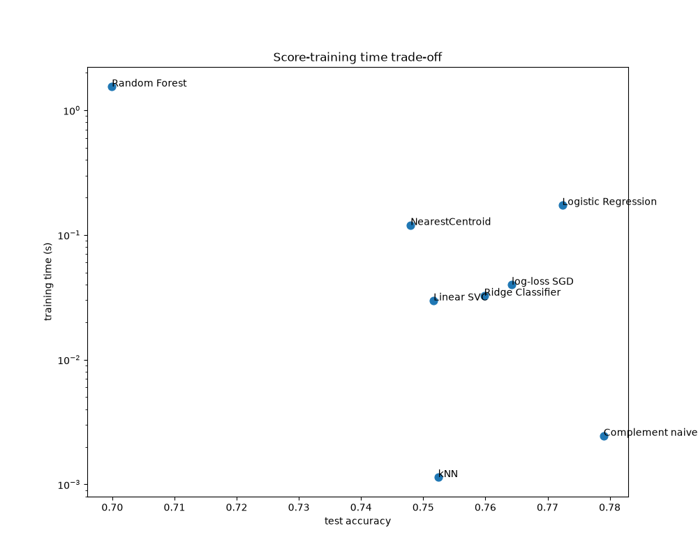

- Desempeño en test

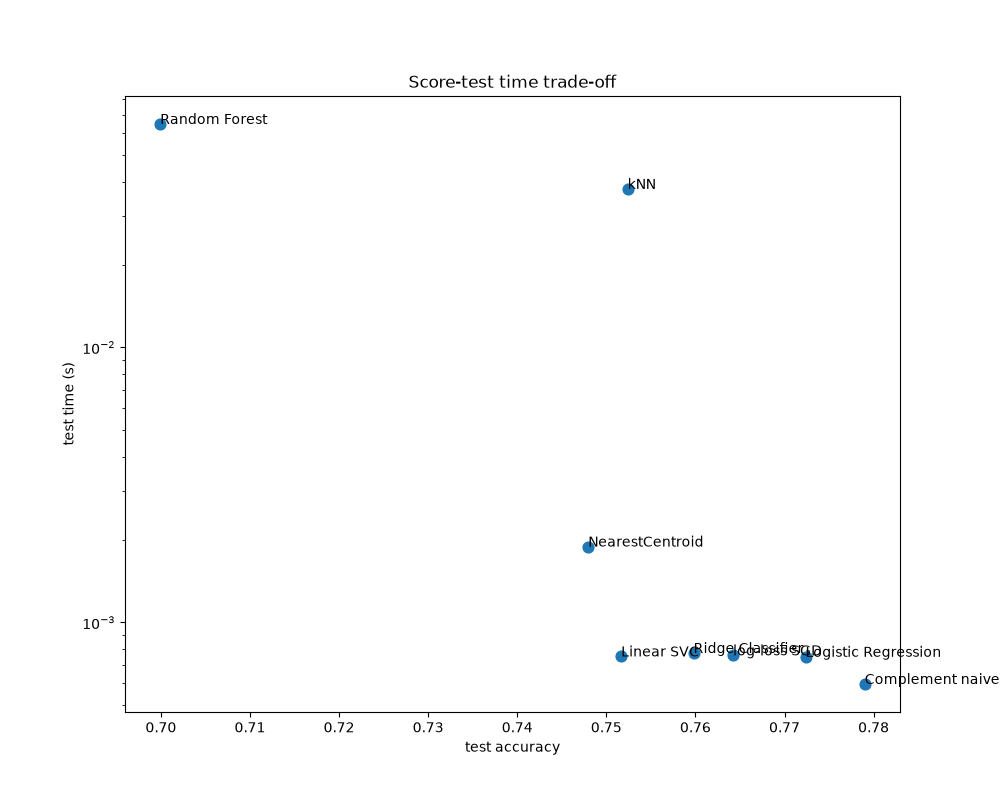

Como se puede apreciar, los mejores modelos para esto son LogisticRegression y ComplementNB (Naive Bayes). Para este caso utilizaremos LogisticRegression pues es el que mejor se acopla a los objetivos del proyecto, con el uso de TF-IDF y SVD.

Se usa regresión logística multiclase con regularización L2. Es una alternativa eficiente para vectores numéricos de baja dimensión, admite las coordenadas positivas y negativas de SVD y permite controlar el ajuste mediante C. Un valor pequeño de C implica mayor regularización.

El modelo aprende fronteras lineales en el espacio latente. Esto facilita su entrenamiento en CPU, aunque puede limitar la separación de ODS con vocabulario compartido. No se justifica comparar muchos algoritmos para cumplir el objetivo del proyecto.

```python
logreg = LogisticRegression(solver='lbfgs', max_iter=500, random_state=STATE)
```

### Creación del pipeline

Con las instancias definidas, definimos los pasos para el pipeline, con el vectorizador y el SVD. Definimos los parámetros de búsqueda que queremos explorar y definimos un modelo que utiliza SVD y otro que no lo utiliza, para validar el aporte de SVD a este ejercicio.

La normalización L2 de las coordenadas latentes y el clasificador controla la longitud de los vectores después de la proyección, que puede variar aunque el TF-IDF original estuviera normalizado.

```python
text_vectorizer = TfidfVectorizer(analyzer=text_analyzer, min_df=2, max_df=0.95, sublinear_tf=True)
text_svd = TruncatedSVD(n_iter=10, random_state=STATE)

steps = [
    ('vectorizer', text_vectorizer),
    ('svd', 'passthrough'),
    ('normalizer', Normalizer(norm='l2')),
    ('model', logreg),
]

C_values = [0.01, 0.1, 1, 10]
class_weight_values = [None, 'balanced']
n_components_values = [10, 15, 20]

param_grid = [
    {'svd': ['passthrough'], 'model__C': C_values, 'model__class_weight': class_weight_values},
    {'svd': [text_svd], 'svd__n_components': n_components_values, 'model__C': C_values, 'model__class_weight': class_weight_values}
]

kfold = StratifiedKFold(n_splits=5, shuffle=True, random_state=STATE)
```

Ahora creamos el objeto de pipeline con los pasos que se presentaron anteriormente, seleccionamos por **F1 macro**, que promedia el F1 de cada ODS con el mismo peso y evita que las clases grandes dominen la elección. También registramos accuracy como referencia. La opción **balanced** asigna pesos inversos a las frecuencias dentro del entrenamiento de cada ajuste; se compara con **None** porque no debe asumirse que ponderar siempre mejora el resultado.

```python
pipeline = Pipeline(steps)

search = GridSearchCV(
    pipeline,
    param_grid,
    scoring={'f1_macro': 'f1_macro', 'accuracy': 'accuracy'},
    refit='f1_macro',
    cv=kfold,
    n_jobs=-1
)
```

### Entrenamiento

Entrenamiento del modelo de clasificación utilizando el pipeline

```python
search.fit(X_train, y_train)
```

```
GridSearchCV(cv=StratifiedKFold(n_splits=5, random_state=42, shuffle=True),
             estimator=Pipeline(steps=[('vectorizer',
                                        TfidfVectorizer(analyzer=<function text_analyzer at 0x00000222204D63E0>,
                                                        max_df=0.95, min_df=2,
                                                        sublinear_tf=True)),
                                       ('svd', 'passthrough'),
                                       ('normalizer', Normalizer()),
                                       ('model',
                                        LogisticRegression(max_iter=500,
                                                           random_state=42))]),
             n_jobs=-1,
             param_grid=[{'model__C': [0.01, 0.1, 1, 10],
                          'model__class_weight': [None, 'balanced'],
                          'svd': ['passthrough']},
                         {'model__C': [0.01, 0.1, 1, 10],
                          'model__class_weight': [None, 'balanced'],
                          'svd': [TruncatedSVD(n_iter=10, random_state=42)],
                          'svd__n_components': [10, 15, 20]}],
             refit='f1_macro',
             scoring={'accuracy': 'accuracy', 'f1_macro': 'f1_macro'})
```

Verificamos los resultados del Grid Search ordenando por el rank del F1 macro mencionado anteriormente

```python
cv_results = pd.DataFrame(search.cv_results_)
display(cv_results.sort_values(by='rank_test_f1_macro', ascending=True).head(10))
```

|  | mean_fit_time | std_fit_time | mean_score_time | std_score_time | param_model__C | param_model__class_weight | param_svd | param_svd__n_components | params | split0_test_f1_macro | ... | std_test_f1_macro | rank_test_f1_macro | split0_test_accuracy | split1_test_accuracy | split2_test_accuracy | split3_test_accuracy | split4_test_accuracy | mean_test_accuracy | std_test_accuracy | rank_test_accuracy |
| --- | --- | --- | --- | --- | --- | --- | --- | --- | --- | --- | --- | --- | --- | --- | --- | --- | --- | --- | --- | --- | --- |
| 6 | 7.739467 | 0.388527 | 1.527688 | 0.036145 | 10.00 | None | passthrough | NaN | {'model__C': 10, 'model__class_weight': None, ... | 0.877736 | ... | 0.009380 | 1 | 0.897087 | 0.885437 | 0.890615 | 0.901618 | 0.877591 | 0.890470 | 0.008477 | 1 |
| 7 | 7.307567 | 0.216715 | 1.505792 | 0.062607 | 10.00 | balanced | passthrough | NaN | {'model__C': 10, 'model__class_weight': 'balan... | 0.874930 | ... | 0.007377 | 2 | 0.893851 | 0.882201 | 0.886731 | 0.897735 | 0.880829 | 0.888269 | 0.006562 | 2 |
| 5 | 7.429872 | 0.069272 | 1.472130 | 0.023944 | 1.00 | balanced | passthrough | NaN | {'model__C': 1, 'model__class_weight': 'balanc... | 0.871936 | ... | 0.011263 | 3 | 0.889320 | 0.876375 | 0.875081 | 0.899029 | 0.871762 | 0.882313 | 0.010271 | 3 |
| 4 | 7.614426 | 0.338495 | 1.562484 | 0.099117 | 1.00 | None | passthrough | NaN | {'model__C': 1, 'model__class_weight': None, '... | 0.861374 | ... | 0.008388 | 4 | 0.882848 | 0.875728 | 0.874434 | 0.893851 | 0.871762 | 0.879724 | 0.007958 | 4 |
| 3 | 6.046276 | 0.124918 | 1.646489 | 0.114223 | 0.10 | balanced | passthrough | NaN | {'model__C': 0.1, 'model__class_weight': 'bala... | 0.850055 | ... | 0.009583 | 5 | 0.866667 | 0.861489 | 0.851133 | 0.878317 | 0.860104 | 0.863542 | 0.008923 | 5 |
| 1 | 6.084348 | 0.213456 | 1.475299 | 0.049249 | 0.01 | balanced | passthrough | NaN | {'model__C': 0.01, 'model__class_weight': 'bal... | 0.846289 | ... | 0.011015 | 6 | 0.863430 | 0.853722 | 0.840777 | 0.871197 | 0.850389 | 0.855903 | 0.010531 | 6 |
| 22 | 6.078274 | 0.116600 | 1.457819 | 0.032624 | 1.00 | None | TruncatedSVD(n_iter=10, random_state=42) | 20.0 | {'model__C': 1, 'model__class_weight': None, '... | 0.786610 | ... | 0.014413 | 7 | 0.831068 | 0.808414 | 0.802589 | 0.812298 | 0.808290 | 0.812532 | 0.009772 | 7 |
| 28 | 6.213526 | 0.131564 | 1.462335 | 0.013626 | 10.00 | None | TruncatedSVD(n_iter=10, random_state=42) | 20.0 | {'model__C': 10, 'model__class_weight': None, ... | 0.780187 | ... | 0.012220 | 8 | 0.826537 | 0.803236 | 0.803883 | 0.812945 | 0.810233 | 0.811367 | 0.008438 | 8 |
| 25 | 6.102635 | 0.096060 | 1.422437 | 0.018729 | 1.00 | balanced | TruncatedSVD(n_iter=10, random_state=42) | 20.0 | {'model__C': 1, 'model__class_weight': 'balanc... | 0.767044 | ... | 0.008273 | 9 | 0.810356 | 0.797411 | 0.800000 | 0.800647 | 0.805052 | 0.802693 | 0.004552 | 9 |
| 31 | 6.138639 | 0.106069 | 0.895264 | 0.025822 | 10.00 | balanced | TruncatedSVD(n_iter=10, random_state=42) | 20.0 | {'model__C': 10, 'model__class_weight': 'balan... | 0.760379 | ... | 0.007790 | 10 | 0.804531 | 0.791586 | 0.796117 | 0.803236 | 0.801813 | 0.799457 | 0.004872 | 10 |

10 rows × 25 columns

Como podemos observar, el mejor modelo no requiere de utilizar SVD

```python
best_model = search.best_estimator_
print('Best model parameters:', search.best_params_)
```

```
Best model parameters: {'model__C': 10, 'model__class_weight': None, 'svd': 'passthrough'}
```

Los mejores parámetros son C=10, sin pesos inversos y omitiendo totalmente el SVD, por lo que podemos concluir que el uso de SVD para este caso no beneficia al modelo.

## Evaluación del modelo

Vamos a evaluar el modelo con los datos de test

```python
y_pred = best_model.predict(X_test)
```

Vamos a ver la matriz de confusion

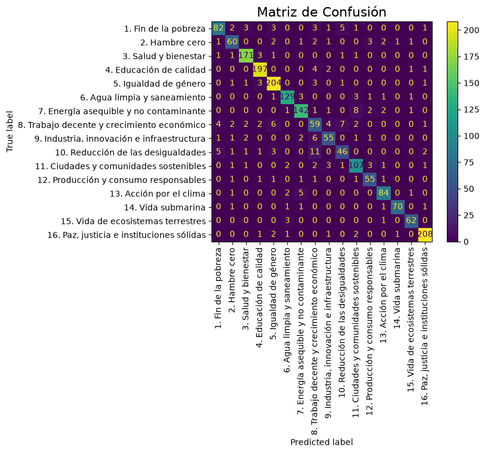

```python
labels = best_model.classes_
display_labels = [f'{idx}. {ods_names[idx]}' for idx in labels]
cm = confusion_matrix(y_test, y_pred, labels=labels)
disp = ConfusionMatrixDisplay(confusion_matrix=cm, display_labels=display_labels)
disp.plot(xticks_rotation=90)
plt.title('Matriz de Confusión', fontsize=16)
plt.show()
```

Y ahora veremos el reporte de clasificación

```python
labels = sorted(y.unique())

names = [f'{idx}. {ods_names[idx]}' for idx in labels]
report = classification_report(y_test, y_pred, labels=labels, target_names=names, zero_division=0, output_dict=True)
report_df = pd.DataFrame(report).T
display(report_df)
```

|  | precision | recall | f1-score | support |
| --- | --- | --- | --- | --- |
| 1. Fin de la pobreza | 0.872340 | 0.811881 | 0.841026 | 101.000000 |
| 2. Hambre cero | 0.833333 | 0.810811 | 0.821918 | 74.000000 |
| 3. Salud y bienestar | 0.944751 | 0.955307 | 0.950000 | 179.000000 |
| 4. Educación de calidad | 0.947115 | 0.960976 | 0.953995 | 205.000000 |
| 5. Igualdad de género | 0.914798 | 0.953271 | 0.933638 | 214.000000 |
| 6. Agua limpia y saneamiento | 0.928058 | 0.928058 | 0.928058 | 139.000000 |
| 7. Energía asequible y no contaminante | 0.916129 | 0.898734 | 0.907348 | 158.000000 |
| 8. Trabajo decente y crecimiento económico | 0.641304 | 0.662921 | 0.651934 | 89.000000 |
| 9. Industria, innovación e infraestructura | 0.808824 | 0.797101 | 0.802920 | 69.000000 |
| 10. Reducción de las desigualdades | 0.754098 | 0.657143 | 0.702290 | 70.000000 |
| 11. Ciudades y comunidades sostenibles | 0.849206 | 0.877049 | 0.862903 | 122.000000 |
| 12. Producción y consumo responsables | 0.846154 | 0.887097 | 0.866142 | 62.000000 |
| 13. Acción por el clima | 0.903226 | 0.903226 | 0.903226 | 93.000000 |
| 14. Vida submarina | 0.972222 | 0.933333 | 0.952381 | 75.000000 |
| 15. Vida de ecosistemas terrestres | 0.925373 | 0.939394 | 0.932331 | 66.000000 |
| 16. Paz, justicia e instituciones sólidas | 0.962963 | 0.962963 | 0.962963 | 216.000000 |
| accuracy | 0.895963 | 0.895963 | 0.895963 | 0.895963 |
| macro avg | 0.876243 | 0.871204 | 0.873317 | 1932.000000 |
| weighted avg | 0.895593 | 0.895963 | 0.895479 | 1932.000000 |

## Análisis de resultados

La evaluación se realizó sobre 1932 textos, que no participaron en el entrenamiento ni en la búsqueda de hiperparámetros. El modelo seleccionado fue el de regresión logística con un `C=10`, sin ponderación de clases y con TF-IDF directo. La búsqueda de hiperparámetros ubicó en el top 6, configuraciones sin SVD, por lo tanto, para estos datos la reducció de dimensionalidad no mejoró la clasificación y se conservó el LSA para la exploración semántica.

El modelo alcanzó un accuracy de 89.6%, con un F1 macro de 87.33% y F1 ponderado de 89.55%. La cercanía entre macro y ponderado indica un desempeño consistente entre las clases, aunque hay que considerar que esto sólo aplica a los 16 ODS que estaban presentes en el conjunto de datos, y que el ODS 17 no tiene textos en el conjunto de datos y no puede ser reconocido por el modelo.

Los resultados más altos se observan en los ODS 3, 4, 5, 14, 16. Lo que nos indica que el vocabulario de estas categorías puede ser separado con alta precisión.

Por el contrario, los ODS 8 (Trabajo decente y crecimiento económico) y 10 (Reducción de las desigualdades) son los que tienen menor desempeño, en la matriz de confusión podemos ver que 7 textos del **ODS 8** fueron clasificados como **ODS 10** y que 11 textos del **ODS 10** fueron clasificados como **ODS 8**. Esto es coherente ya que el vocabulario utilizado en ambas instancias puede ser similar por el tema de trabajo, ingresos, desigualdad.

## Conclusiones

La principal limitación es que la cobertura actual no abarca el ODS 17, pues estaba ausente en el conjunto de datos suministrado. Es por esto que el sistema no debe presentarse como solución capaz de clasificar los 17 ODS, sino que clasifica las 16 categorías con datos disponibles. Una futura iteración debería incluir textos nuevos y traducidos para este ODS 17.

El uso de la validación cruzada y la elección del F1 macro, evita basar la decisión únicamente en las clases más frecuentes.

Un mismo ODS puede aparecer en más de un componente de SVD, pues entre ellos existen temas relacionados.

En la búsqueda cruzada con GridSearchCV se determinó que el modelo directo, sin SVD, se desempeñó mejor que otros que sí lo usan. Esto se respalda en el score F1 macro con 87.33% y un accuracy de 89.6% en los test.